# Analyses of ecological stability of freshwater communities exposed to insectiside

Viktoriia Radchuk

26/05/2026

# Overview of the data

We illustrate the use of `estar` functions on a dataset from an ecotoxicological study about the effects of the chlorpyrifos insecticide on a community of aquatic macroinvertebrates [@van_den_brink_effects_1996; @wijngaarden_effects_1996]. The insecticide negatively affects freshwater macroinvertebrates, and, to a lesser degree, zooplankton species. This insecticide was applied at four different concentrations (0.1, 0.9, 6, and 44 microg/ L), with two replicates per concentration level. Additionally, four replicates were used as control, undisturbed systems (‘baseline’ in `estar` terminology). The community is composed of 128 species, classified into 5 functional groups: herbivores, detriti-herbivores, carnivores, omnivores, and detritivores.

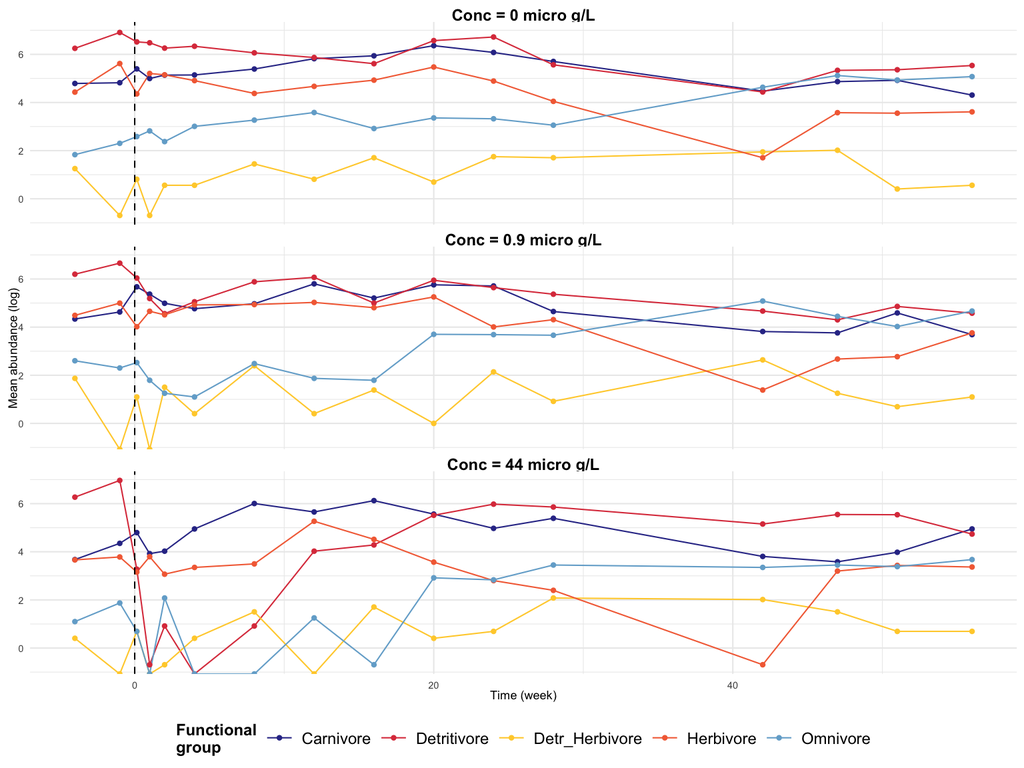

Figure 1. Organism mean count (log axis) of the five functional groups over the course of ecotoxicological experiment. The vertical dashed line identifies the time when the insecticide was applied (at week 0), and facets represent the different concentrations (micro g/L).

# Functional stability metrics

```r
aquacomm_fgps
```

```
## # A tibble: 192 × 8
## # Rowwise:
##     time repli treat  herb detr_herb  carn  omni  detr
##    <dbl> <dbl> <dbl> <dbl>     <dbl> <dbl> <dbl> <dbl>
##  1 -4        2     0    73         7   101     7   568
##  2 -1        2     0   220         1   102    20   922
##  3  0.14     2     0   126         7   184    10   573
##  4  1        2     0   101         0   200    10   326
##  5  2        2     0   166         3   192    10   359
##  6  4        2     0   166         2   216    10   496
##  7  8        2     0    94         5   208    11   200
##  8 12        2     0    53         1   237    28   238
##  9 16        2     0    48         1   226     2   110
## 10 20        2     0    72         0   508    12   930
## # ℹ 182 more rows
```

```r
unique(aquacomm_fgps$time)
```

```
##  [1] -4.00 -1.00  0.14  1.00  2.00  4.00  8.00 12.00 16.00 20.00 24.00 28.00
## [13] 42.00 47.00 51.00 56.00
```

Pay attention to the time periods between samplings!

For this demonstration, let us look at the stability of detritivores in one of the ditches with the highest concentration of insecticide.

```r
detr <- aquacomm_fgps |>
  select(time, repli, treat, detr) |>
  filter(treat %in% c(0, 44) & repli %in% c(5,9)) |>
  select(-repli) |>
  tidyr::pivot_wider(names_from = treat, values_from = detr, names_prefix = "detr_") |>
  mutate_if(is.numeric, ~ ifelse(. == 0, .+1, .)) |>  # 0 abundances will return Inf for resp ratio
  dplyr::select(time, "statvar_bl" = detr_0, "statvar_db" = detr_44)
```

Let us plot the data for selected ditches to look closer at the dynamics.

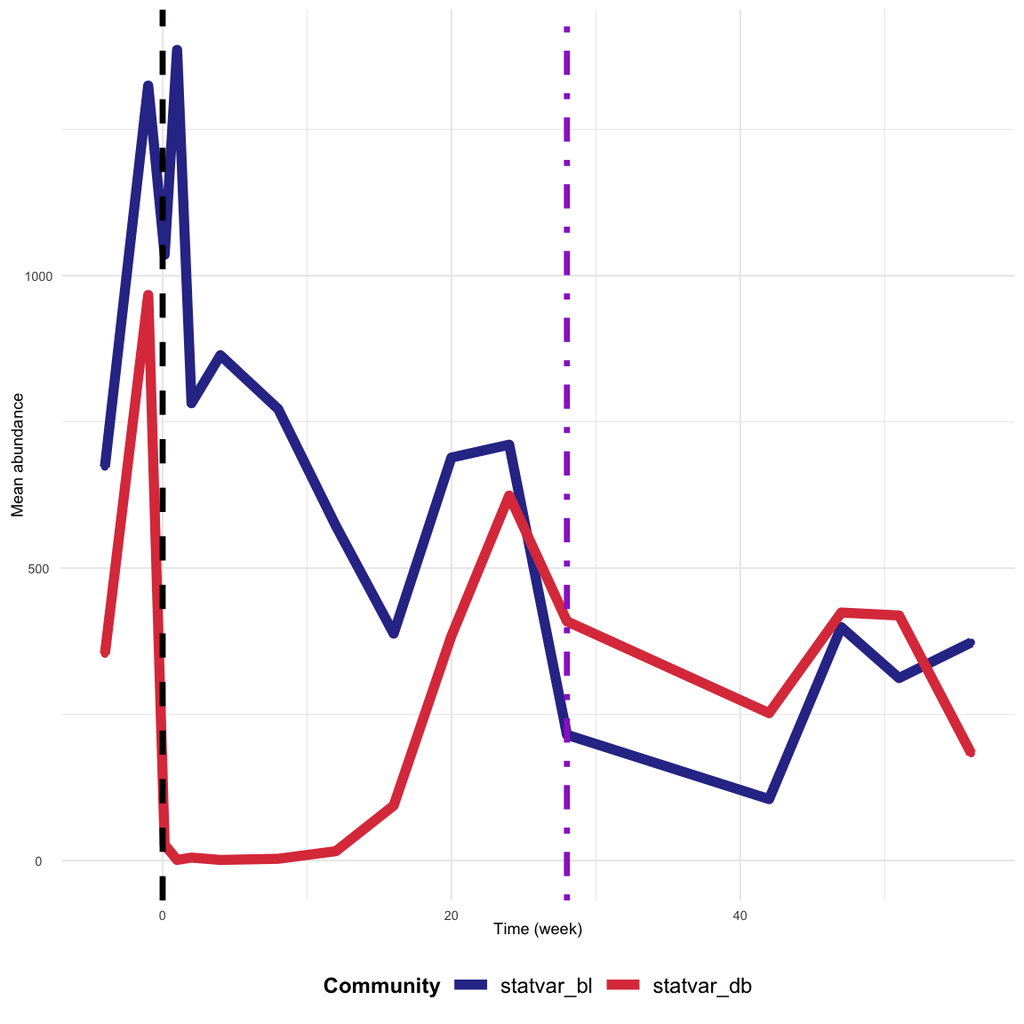

Figure 2. Abundance of detritivores in one selected disturbed (44 micro g/L) and one reference ditch over the course of ecotoxicological experiment. The vertical black dashed line identifies the time when the insecticide was applied and the vertical violet line - week 28 by which the recovery is expected to occur.

Examples of each function applied to the example dataset. For the functions that require a user-defined time step when the system has recovered, we use week 28, when all groups seem to have stabilized their growth curve based on visual inspection (Fig.1).

### Invariability

Calculated as the inverse of the coefficient of variation of the log response ratio of the state variable in the disturbed and baseline systems.

```r
invariability(
  type = "functional",
  response = "lrr",
  mode = "cv",
  metric_tf = c(1, 28),
  vd_i = "statvar_db",
  td_i = "time",
  b_data = detr,
  vb_i = "statvar_bl",
  tb_i = "time",
  d_data = detr
)
```

```
## [1] 1.097315
```

### Resistance

Resistance calculated in relation to an independent baseline time series (`b = "input"`), as the log response ratio (`res_mode = "lrr"`) of the state variable in the disturbed and baseline systems at the first time step following disturbance (`res_time = "defined"`, `res_t = 1`).

```r
resistance(
  type = "functional",
  b = "input",
  res_mode = "lrr",
  res_time = "defined",
  res_t = 1,
  vd_i = "statvar_db",
  td_i = "time",
  d_data = detr,
  vb_i = "statvar_bl",
  tb_i = "time",
  b_data = detr
)
```

```
## [1] -7.234177
```

```r
resistance(
  type = "functional",
  b = "d",
  b_tf = c(-4, -1),
  res_mode = "lrr",
  res_time = "defined",
  res_t = 1,
  vd_i = "statvar_db",
  td_i = "time",
  d_data = detr
)
```

```
## [1] -6.49224
```

### Extent of recovery

Extent of recovery calculated as the log response ratio (`response = "lrr"`) of the state variable in the disturbed and baseline independent systems (`b = "input"`), at a user-defined time step when recovery is assumed to have happened (`t_rec = 28`).

```r
recovery_extent(
  type = "functional",
  response = "lrr",
  b = "input",
  t_rec = 28,
  vd_i = "statvar_db",
  td_i = "time",
  d_data = detr,
  vb_i = "statvar_bl",
  tb_i = "time",
  b_data = detr
)
```

```
## [1] 0.6430771
```

Extent of recovery calculated as the log response ratio (`response = "lrr"`) of the state variable in the disturbed time-series relative to the pre-disturbance period (`b = "d"`), summarized by the mean value (`summ_mode = "mean"` - default, over a period `b_tf = c(-4, -1)`). The extent of recovery is calculated at the point when we assume recovery have happened (`t_rec = 28`).

```r
recovery_extent(
  type = "functional",
  response = "lrr",
  b = "d",
  summ_mode = "mean",
  b_tf = c(-4, -1),
  t_rec = 28,
  vd_i = "statvar_db",
  td_i = "time",
  d_data = detr
)
```

```
## [1] -0.4785247
```

### Rate of recovery

Rate of recovery calculated as the slope of the linear model which predicts the log response ratio of the state variable in the disturbed system compared to the baseline (`b = "input"`) by time (from one week after disturbance and until recovery, `metric_tf = c(1, 28)`).

```r
recovery_rate(
  type = "functional",
  response = "lrr",
  b = "input",
  metric_tf = c(1, 28),
  vd_i = "statvar_db",
  td_i = "time",
  d_data = detr,
  vb_i = "statvar_bl",
  tb_i = "time",
  b_data = detr
)
```

```
## [1] 0.2937793
```

### Persistence

Proportion of time over which the state variable stays within 1 standard deviation from the mean of the state variable values from an independent baseline (`b = "input"`) over the period specified by the user, often since application of the disturbance and until the recovery is expected to happen (`metric_tf = c(1, 28)`).

```r
persistence(
  type = "functional",
  b = "input",
  metric_tf = c(1, 28),
  vd_i = "statvar_db",
  td_i = "time",
  d_data = detr,
  vb_i = "statvar_bl",
  tb_i = "time",
  b_data = detr
)
```

```
## [1] 0.3333333
```

```r
persistence(
  type = "functional",
  b = "d",
  b_tf = c(-4, -1),
  metric_tf = c(1, 28),
  vd_i = "statvar_db",
  td_i = "time",
  d_data = detr
)
```

```
## [1] 0.3333333
```

### Overall Ecological Vulnerability

```r
oev(
  type = "functional",
  response = "lrr",
  metric_tf = c(1, 28),
  vd_i = "statvar_db",
  td_i = "time",
  d_data = detr,
  vb_i = "statvar_bl",
  tb_i = "time",
  b_data = detr
)
```

```
## [1] 75.23329
```

# Compositional stability

Calculated using community compositional data for the disturbed and a baseline (reference) community. To do so, the functions call the `vegdist` function (from the `vegan` package), to which we can pass on the required `method` and `binary` arguments. Here, we use the default settings for arguments `method` and `binary`, i.e. the Bray-Curtis dissimilarity.

```r
# Reformatting the macroinvertebrate community long-format data into
# community composition data
comm_data <- aquacomm_fgps |>
    dplyr::group_by(time, treat) |>
    dplyr::filter(treat %in% c(0, 44)) |>
    dplyr::summarize_at(vars(herb, detr_herb, carn, omni, detr),
                        mean) |>
    dplyr::ungroup()

control_comm <- comm_data |>
        dplyr::filter(treat == 0) |>
        dplyr::select(-treat)
dist_comm <- comm_data |>
        dplyr::filter(treat == 44) |>
        dplyr::select(-treat)
```

### Invariability

Invariability calculated as the coefficient of variation of dissimilarity between disturbed and control systems since one week after disturbance and until recovery is assumed to have happened (`metric_tf = c(1, 28)`).

```r
invariability(
  type = "compositional",
  metric_tf = c(1, 28),
  comm_d = dist_comm,
  comm_b = control_comm,
  comm_t = "time")
```

[output not shown]

### Resistance

Resistance calculated one week after pulse disturbance (`res_time = "defined"`, `res_t = 1`).

```r
resistance(type = "compositional",
          res_time = "defined",
          res_t = 1,
          comm_d = dist_comm,
          comm_b = control_comm,
          comm_t = "time")
```

[output not shown]

### Rate of recovery

Rate of recovery of the community over the period from the first week after the disturbance and an assumed recovery at week 28 (`metric_tf = c(1, 28)`).

```r
recovery_rate(type = "compositional",
              metric_tf = c(1, 28),
              comm_d = dist_comm,
              comm_b = control_comm,
              comm_t = "time")
```

```
## [1] -0.02034013
```

### Extent of recovery

Since we assume recovery happened by week 28, we calculate its extent by that time (`t_rec = 28`).

```r
recovery_extent(type = "compositional",
          t_rec = 28,
          comm_d = dist_comm,
          comm_b = control_comm,
          comm_t = "time")
```

```
## [1] 0.1808847
```

### Persistence

Here, the community is considered to be persistent if it’s dissimilarity with the undisturbed, baseline community stays between 0.5 and 0.9 (`low_lim = 0.5, high_lim = 0.9`). We compute the proportion of time the disturbed community stayed in this persistence “zone” from one week after disturbance and until assumed recovery (week 28, `metric_tf = c(1, 28)`).

```r
persistence(type = "compositional",
            b = "input",
            metric_tf = c(1, 28),
            comm_d = dist_comm,
            comm_b = control_comm,
            comm_t = "time",
            low_lim = 0.5,
            high_lim = 0.9)
```

```
## [1] 0.4444444
```

### Overall Ecological Vulnerability

```r
oev(type = "compositional",
    metric_tf = c(1, 28),
    comm_d = dist_comm,
    comm_b = control_comm,
    comm_t = "time")
```

```
## [1] 12.22054
```